# R Lab: Data Structures - Vectors and Lists

Laiza Joy Berganio

2026-10-29

## Part A — Creating Vectors and List:

**Question #1:**

A factory has a census of its workers. There are 50 workers in total. The following list shows their ages: `34, 28, 22, 36, 27, 18, 52, 39, 42, 29, 35, 31, 27, 22, 37, 34, 19, 20, 57, 49, 50, 37, 46, 25, 17, 37, 43, 53, 41, 51, 35, 24,33, 41, 53, 40, 18, 44, 38, 41, 48, 27, 39, 19, 30, 61, 54, 58, 26, 18.

1. Create a vector for the worker’s age.

```r
workerAge <- c(34, 28, 22, 36, 27, 18, 52, 39, 42, 29, 35, 31, 27, 22, 37, 34, 19, 20, 57, 49, 50, 37, 46, 25, 17, 37, 43, 53, 41, 51, 35, 24,33, 41, 53, 40, 18, 44, 38, 41, 48, 27, 39, 19, 30, 61, 54, 58, 26, 18)
workerAge
```

```
##  [1] 34 28 22 36 27 18 52 39 42 29 35 31 27 22 37 34 19 20 57 49 50 37 46 25 17
## [26] 37 43 53 41 51 35 24 33 41 53 40 18 44 38 41 48 27 39 19 30 61 54 58 26 18
```

2. How many data points?

```r
length(workerAge)
```

```
## [1] 50
```

There are 50 data points for the vector `workerAge`.

3. Find the minimum and the maximum value of worker’s age.

```r
min(workerAge)
```

```
## [1] 17
```

```r
max(workerAge)
```

```
## [1] 61
```

The minimum and maximum value of `workerAge` are 17 and 61 respectively.

4. Access the 13rd to 18th elements and 33th to 35th elements of worker’s Age.

```r
workerAge[c(13:18, 33:35)]
```

```
## [1] 27 22 37 34 19 20 33 41 53
```

5. Access all but the 10th, 20th, 30th and 40th elements are not included.

```r
workerAge[-c(10, 20, 30, 40)]
```

```
##  [1] 34 28 22 36 27 18 52 39 42 35 31 27 22 37 34 19 20 57 50 37 46 25 17 37 43
## [26] 53 41 35 24 33 41 53 40 18 44 38 48 27 39 19 30 61 54 58 26 18
```

6. Modify the 4th, 14th, 24th, and 44th elements with value = 0.

```r
workerAge[c(4, 14, 24, 44)] <- 0
workerAge
```

```
##  [1] 34 28 22  0 27 18 52 39 42 29 35 31 27  0 37 34 19 20 57 49 50 37 46  0 17
## [26] 37 43 53 41 51 35 24 33 41 53 40 18 44 38 41 48 27 39  0 30 61 54 58 26 18
```

**Question #2:**

- R has actually lots of built-in datasets.
- For example, the rivers data “gives the lengths (in miles) of 141 “major” rivers in North America, as compiled by the US Geological Survey”.
- Use `data(rivers)`
1. Get the number of elements (length) in rivers, their sum (sum), mean (mean), median(median), variance(var), standard deviation(sd), minimum (min) and maximum (max).

```r
data(rivers)

river_stats <- c(
  length = length(rivers),
  sum    = sum(rivers),
  mean   = mean(rivers),
  median = median(rivers),
  var    = var(rivers),
  sd     = sd(rivers),
  min    = min(rivers),
  max    = max(rivers)
)
```

2. What is the result? The derived result must be in just one(1) vector name.

```r
river_stats
```

```
##      length         sum        mean      median         var          sd
##    141.0000  83357.0000    591.1844    425.0000 243908.4086    493.8708
##         min         max
##    135.0000   3710.0000
```

**Question #3:**

- The table below gives the 25 most powerful celebrities and their annual pay as ranked by the editions of Forbes magazine and as listed on the Forbes.com website.

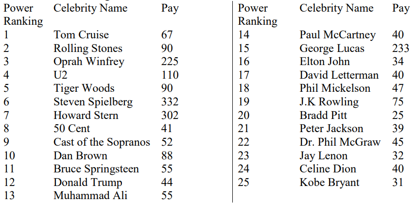

1. Create vectors according to the above table.

```r
power_ranking <- 1:25

celebrity <- c(
  "Tom Cruise", "Rolling Stones", "Oprah Winfrey", "U2",
  "Tiger Woods", "Steven Spielberg", "Howard Stern", "50 Cent",
  "Cast of the Sopranos", "Dan Brown", "Bruce Springsteen",
  "Donald Trump", "Muhammad Ali", "Paul McCartney", "George Lucas",
  "Elton John", "David Letterman", "Phil Mickelson", "J.K. Rowling",
  "Bradd Pitt", "Peter Jackson", "Dr. Phil McGraw", "Jay Lenon",
  "Celine Dion", "Kobe Bryant"
)

pay <- c(
  67, 90, 225, 110, 90, 332, 302, 41, 52, 88,
  55, 44, 55, 40, 233, 34, 40, 47, 75, 25,
  39, 45, 32, 40, 31
)

names(power_ranking) <- celebrity
names(pay) <- celebrity

power_ranking
```

```
##           Tom Cruise       Rolling Stones        Oprah Winfrey
##                    1                    2                    3
##                   U2          Tiger Woods     Steven Spielberg
##                    4                    5                    6
##         Howard Stern              50 Cent Cast of the Sopranos
##                    7                    8                    9
##            Dan Brown    Bruce Springsteen         Donald Trump
##                   10                   11                   12
##         Muhammad Ali       Paul McCartney         George Lucas
##                   13                   14                   15
##           Elton John      David Letterman       Phil Mickelson
##                   16                   17                   18
##         J.K. Rowling           Bradd Pitt        Peter Jackson
##                   19                   20                   21
##      Dr. Phil McGraw            Jay Lenon          Celine Dion
##                   22                   23                   24
##          Kobe Bryant
##                   25
```

```r
pay
```

```
##           Tom Cruise       Rolling Stones        Oprah Winfrey
##                   67                   90                  225
##                   U2          Tiger Woods     Steven Spielberg
##                  110                   90                  332
##         Howard Stern              50 Cent Cast of the Sopranos
##                  302                   41                   52
##            Dan Brown    Bruce Springsteen         Donald Trump
##                   88                   55                   44
##         Muhammad Ali       Paul McCartney         George Lucas
##                   55                   40                  233
##           Elton John      David Letterman       Phil Mickelson
##                   34                   40                   47
##         J.K. Rowling           Bradd Pitt        Peter Jackson
##                   75                   25                   39
##      Dr. Phil McGraw            Jay Lenon          Celine Dion
##                   45                   32                   40
##          Kobe Bryant
##                   31
```

There are now three vectors for the power ranking, celebrities, and the pay, containing the information in the table.

2. Modify the power ranking and pay of J.K. Rowling. Change power ranking to 15 and pay to 90.

   ```r
   power_ranking["J.K. Rowling"] <- 15
   pay["J.K. Rowling"] <- 90

   power_ranking["J.K. Rowling"]
   ```

   ```
   ## J.K. Rowling
   ##           15
   ```

   ```r
   pay["J.K. Rowling"]
   ```

   ```
   ## J.K. Rowling
   ##           90
   ```

   The power ranking and pay of J.K. Rowling is now 15 and 90.

**Question #4:**

- Create a list of ten (10) vegetables you ate during your lifetime. If none, just list down the vegetables in your mind.

```r
vegetables <- list(
  "Carrot", "Sitaw", "Ampalaya", "Potato", "Tomato",
  "Malunggay", "Onion", "Garlic", "Cabbage", "Sweet Potato"
)
vegetables
```

```
## [[1]]
## [1] "Carrot"
##
## [[2]]
## [1] "Sitaw"
##
## [[3]]
## [1] "Ampalaya"
##
## [[4]]
## [1] "Potato"
##
## [[5]]
## [1] "Tomato"
##
## [[6]]
## [1] "Malunggay"
##
## [[7]]
## [1] "Onion"
##
## [[8]]
## [1] "Garlic"
##
## [[9]]
## [1] "Cabbage"
##
## [[10]]
## [1] "Sweet Potato"
```

1. Add 2 additional vegetables after the last vegetables in the list. What is the result?

```r
vegetables <- append(vegetables, c("Eggplant", "Radish"))
vegetables
```

```
## [[1]]
## [1] "Carrot"
##
## [[2]]
## [1] "Sitaw"
##
## [[3]]
## [1] "Ampalaya"
##
## [[4]]
## [1] "Potato"
##
## [[5]]
## [1] "Tomato"
##
## [[6]]
## [1] "Malunggay"
##
## [[7]]
## [1] "Onion"
##
## [[8]]
## [1] "Garlic"
##
## [[9]]
## [1] "Cabbage"
##
## [[10]]
## [1] "Sweet Potato"
##
## [[11]]
## [1] "Eggplant"
##
## [[12]]
## [1] "Radish"
```

It shows the 2 additional vegetables in the end of the list.

2. How many data points do you have?

```r
length(vegetables)
```

```
## [1] 12
```

There are 12 data points for the vegetable list.

3. Add 4 additional vegetables after index 5. What is the result?

```r
vegetables <- append(
  vegetables,
  c("Monggo", "Pumpkin", "Pechay", "Upo"),
  after = 5
)
vegetables
```

```
## [[1]]
## [1] "Carrot"
##
## [[2]]
## [1] "Sitaw"
##
## [[3]]
## [1] "Ampalaya"
##
## [[4]]
## [1] "Potato"
##
## [[5]]
## [1] "Tomato"
##
## [[6]]
## [1] "Monggo"
##
## [[7]]
## [1] "Pumpkin"
##
## [[8]]
## [1] "Pechay"
##
## [[9]]
## [1] "Upo"
##
## [[10]]
## [1] "Malunggay"
##
## [[11]]
## [1] "Onion"
##
## [[12]]
## [1] "Garlic"
##
## [[13]]
## [1] "Cabbage"
##
## [[14]]
## [1] "Sweet Potato"
##
## [[15]]
## [1] "Eggplant"
##
## [[16]]
## [1] "Radish"
```

It now shows the added vegetables after index 5.

4. How many data points does your vegetable list have?

```r
length(vegetables)
```

```
## [1] 16
```

The vegetable list now has 16 data points.